# Risk Factor Analysis

## Outcome Variable

**Outcome Variable:** ever_stunted

## Predictor Variables

**Intervention Variable:** brthmon

**Adjustment Set:**

unadjusted

## Stratifying Variables

The analysis was stratified on these variable(s):

- agecat
- studyid
- country

## Data Summary

| agecat | studyid | country | brthmon | ever_stunted | n_cell | n |
| --- | --- | --- | --- | --- | --- | --- |
| 0-24 months | ki0047075b-MAL-ED | BANGLADESH | 1 | 0 | 8 | 265 |
| 0-24 months | ki0047075b-MAL-ED | BANGLADESH | 1 | 1 | 13 | 265 |
| 0-24 months | ki0047075b-MAL-ED | BANGLADESH | 2 | 0 | 7 | 265 |
| 0-24 months | ki0047075b-MAL-ED | BANGLADESH | 2 | 1 | 18 | 265 |
| 0-24 months | ki0047075b-MAL-ED | BANGLADESH | 3 | 0 | 8 | 265 |
| 0-24 months | ki0047075b-MAL-ED | BANGLADESH | 3 | 1 | 17 | 265 |
| 0-24 months | ki0047075b-MAL-ED | BANGLADESH | 4 | 0 | 12 | 265 |
| 0-24 months | ki0047075b-MAL-ED | BANGLADESH | 4 | 1 | 10 | 265 |
| 0-24 months | ki0047075b-MAL-ED | BANGLADESH | 5 | 0 | 5 | 265 |
| 0-24 months | ki0047075b-MAL-ED | BANGLADESH | 5 | 1 | 17 | 265 |
| 0-24 months | ki0047075b-MAL-ED | BANGLADESH | 6 | 0 | 5 | 265 |
| 0-24 months | ki0047075b-MAL-ED | BANGLADESH | 6 | 1 | 6 | 265 |
| 0-24 months | ki0047075b-MAL-ED | BANGLADESH | 7 | 0 | 7 | 265 |
| 0-24 months | ki0047075b-MAL-ED | BANGLADESH | 7 | 1 | 13 | 265 |
| 0-24 months | ki0047075b-MAL-ED | BANGLADESH | 8 | 0 | 10 | 265 |
| 0-24 months | ki0047075b-MAL-ED | BANGLADESH | 8 | 1 | 16 | 265 |
| 0-24 months | ki0047075b-MAL-ED | BANGLADESH | 9 | 0 | 10 | 265 |
| 0-24 months | ki0047075b-MAL-ED | BANGLADESH | 9 | 1 | 13 | 265 |
| 0-24 months | ki0047075b-MAL-ED | BANGLADESH | 10 | 0 | 13 | 265 |
| 0-24 months | ki0047075b-MAL-ED | BANGLADESH | 10 | 1 | 12 | 265 |
| 0-24 months | ki0047075b-MAL-ED | BANGLADESH | 11 | 0 | 8 | 265 |
| 0-24 months | ki0047075b-MAL-ED | BANGLADESH | 11 | 1 | 9 | 265 |
| 0-24 months | ki0047075b-MAL-ED | BANGLADESH | 12 | 0 | 11 | 265 |
| 0-24 months | ki0047075b-MAL-ED | BANGLADESH | 12 | 1 | 17 | 265 |
| 0-24 months | ki0047075b-MAL-ED | BRAZIL | 1 | 0 | 12 | 233 |
| 0-24 months | ki0047075b-MAL-ED | BRAZIL | 1 | 1 | 3 | 233 |
| 0-24 months | ki0047075b-MAL-ED | BRAZIL | 2 | 0 | 18 | 233 |
| 0-24 months | ki0047075b-MAL-ED | BRAZIL | 2 | 1 | 7 | 233 |
| 0-24 months | ki0047075b-MAL-ED | BRAZIL | 3 | 0 | 16 | 233 |
| 0-24 months | ki0047075b-MAL-ED | BRAZIL | 3 | 1 | 4 | 233 |

[output cut: 2034 more lines]

The following strata were considered:

- agecat: 0-24 months, studyid: ki0047075b-MAL-ED, country: BANGLADESH
- agecat: 0-24 months, studyid: ki0047075b-MAL-ED, country: BRAZIL
- agecat: 0-24 months, studyid: ki0047075b-MAL-ED, country: INDIA
- agecat: 0-24 months, studyid: ki0047075b-MAL-ED, country: NEPAL
- agecat: 0-24 months, studyid: ki0047075b-MAL-ED, country: PERU
- agecat: 0-24 months, studyid: ki0047075b-MAL-ED, country: SOUTH AFRICA
- agecat: 0-24 months, studyid: ki0047075b-MAL-ED, country: TANZANIA, UNITED REPUBLIC OF
- agecat: 0-24 months, studyid: ki1000108-CMC-V-BCS-2002, country: INDIA
- agecat: 0-24 months, studyid: ki1000108-IRC, country: INDIA
- agecat: 0-24 months, studyid: ki1000109-EE, country: PAKISTAN
- agecat: 0-24 months, studyid: ki1000109-ResPak, country: PAKISTAN
- agecat: 0-24 months, studyid: ki1000304b-SAS-CompFeed, country: INDIA
- agecat: 0-24 months, studyid: ki1000304b-SAS-FoodSuppl, country: INDIA
- agecat: 0-24 months, studyid: ki1017093-NIH-Birth, country: BANGLADESH
- agecat: 0-24 months, studyid: ki1066203-TanzaniaChild2, country: TANZANIA, UNITED REPUBLIC OF
- agecat: 0-24 months, studyid: ki1101329-Keneba, country: GAMBIA
- agecat: 0-24 months, studyid: ki1112895-Guatemala BSC, country: GUATEMALA
- agecat: 0-24 months, studyid: ki1112895-iLiNS-Zinc, country: BURKINA FASO
- agecat: 0-24 months, studyid: ki1113344-GMS-Nepal, country: NEPAL
- agecat: 0-24 months, studyid: ki1114097-CMIN, country: BANGLADESH
- agecat: 0-24 months, studyid: ki1114097-CMIN, country: BRAZIL
- agecat: 0-24 months, studyid: ki1114097-CMIN, country: GUINEA-BISSAU
- agecat: 0-24 months, studyid: ki1114097-CMIN, country: PERU
- agecat: 0-24 months, studyid: ki1114097-CONTENT, country: PERU
- agecat: 0-24 months, studyid: ki1119695-PROBIT, country: BELARUS
- agecat: 0-24 months, studyid: ki1126311-ZVITAMBO, country: ZIMBABWE
- agecat: 0-24 months, studyid: ki1148112-LCNI-5, country: MALAWI
- agecat: 0-24 months, studyid: kiGH5241-JiVitA-3, country: BANGLADESH
- agecat: 0-24 months, studyid: kiGH5241-JiVitA-4, country: BANGLADESH
- agecat: 0-6 months, studyid: ki0047075b-MAL-ED, country: BANGLADESH
- agecat: 0-6 months, studyid: ki0047075b-MAL-ED, country: BRAZIL
- agecat: 0-6 months, studyid: ki0047075b-MAL-ED, country: INDIA
- agecat: 0-6 months, studyid: ki0047075b-MAL-ED, country: NEPAL
- agecat: 0-6 months, studyid: ki0047075b-MAL-ED, country: PERU
- agecat: 0-6 months, studyid: ki0047075b-MAL-ED, country: SOUTH AFRICA
- agecat: 0-6 months, studyid: ki0047075b-MAL-ED, country: TANZANIA, UNITED REPUBLIC OF
- agecat: 0-6 months, studyid: ki1000108-CMC-V-BCS-2002, country: INDIA
- agecat: 0-6 months, studyid: ki1000108-IRC, country: INDIA
- agecat: 0-6 months, studyid: ki1000109-EE, country: PAKISTAN
- agecat: 0-6 months, studyid: ki1000109-ResPak, country: PAKISTAN
- agecat: 0-6 months, studyid: ki1000304b-SAS-CompFeed, country: INDIA
- agecat: 0-6 months, studyid: ki1000304b-SAS-FoodSuppl, country: INDIA
- agecat: 0-6 months, studyid: ki1017093-NIH-Birth, country: BANGLADESH
- agecat: 0-6 months, studyid: ki1066203-TanzaniaChild2, country: TANZANIA, UNITED REPUBLIC OF
- agecat: 0-6 months, studyid: ki1101329-Keneba, country: GAMBIA
- agecat: 0-6 months, studyid: ki1112895-Guatemala BSC, country: GUATEMALA
- agecat: 0-6 months, studyid: ki1113344-GMS-Nepal, country: NEPAL
- agecat: 0-6 months, studyid: ki1114097-CMIN, country: BANGLADESH
- agecat: 0-6 months, studyid: ki1114097-CMIN, country: BRAZIL
- agecat: 0-6 months, studyid: ki1114097-CMIN, country: GUINEA-BISSAU
- agecat: 0-6 months, studyid: ki1114097-CMIN, country: PERU
- agecat: 0-6 months, studyid: ki1114097-CONTENT, country: PERU
- agecat: 0-6 months, studyid: ki1119695-PROBIT, country: BELARUS
- agecat: 0-6 months, studyid: ki1126311-ZVITAMBO, country: ZIMBABWE
- agecat: 0-6 months, studyid: ki1148112-LCNI-5, country: MALAWI
- agecat: 0-6 months, studyid: kiGH5241-JiVitA-3, country: BANGLADESH
- agecat: 0-6 months, studyid: kiGH5241-JiVitA-4, country: BANGLADESH
- agecat: 6-24 months, studyid: ki0047075b-MAL-ED, country: BANGLADESH
- agecat: 6-24 months, studyid: ki0047075b-MAL-ED, country: BRAZIL
- agecat: 6-24 months, studyid: ki0047075b-MAL-ED, country: INDIA
- agecat: 6-24 months, studyid: ki0047075b-MAL-ED, country: NEPAL
- agecat: 6-24 months, studyid: ki0047075b-MAL-ED, country: PERU
- agecat: 6-24 months, studyid: ki0047075b-MAL-ED, country: SOUTH AFRICA
- agecat: 6-24 months, studyid: ki0047075b-MAL-ED, country: TANZANIA, UNITED REPUBLIC OF
- agecat: 6-24 months, studyid: ki1000108-CMC-V-BCS-2002, country: INDIA
- agecat: 6-24 months, studyid: ki1000108-IRC, country: INDIA
- agecat: 6-24 months, studyid: ki1000109-EE, country: PAKISTAN
- agecat: 6-24 months, studyid: ki1000109-ResPak, country: PAKISTAN
- agecat: 6-24 months, studyid: ki1000304b-SAS-CompFeed, country: INDIA
- agecat: 6-24 months, studyid: ki1000304b-SAS-FoodSuppl, country: INDIA
- agecat: 6-24 months, studyid: ki1017093-NIH-Birth, country: BANGLADESH
- agecat: 6-24 months, studyid: ki1066203-TanzaniaChild2, country: TANZANIA, UNITED REPUBLIC OF
- agecat: 6-24 months, studyid: ki1101329-Keneba, country: GAMBIA
- agecat: 6-24 months, studyid: ki1112895-Guatemala BSC, country: GUATEMALA
- agecat: 6-24 months, studyid: ki1112895-iLiNS-Zinc, country: BURKINA FASO
- agecat: 6-24 months, studyid: ki1113344-GMS-Nepal, country: NEPAL
- agecat: 6-24 months, studyid: ki1114097-CMIN, country: BANGLADESH
- agecat: 6-24 months, studyid: ki1114097-CMIN, country: BRAZIL
- agecat: 6-24 months, studyid: ki1114097-CMIN, country: GUINEA-BISSAU
- agecat: 6-24 months, studyid: ki1114097-CMIN, country: PERU
- agecat: 6-24 months, studyid: ki1114097-CONTENT, country: PERU
- agecat: 6-24 months, studyid: ki1119695-PROBIT, country: BELARUS
- agecat: 6-24 months, studyid: ki1126311-ZVITAMBO, country: ZIMBABWE
- agecat: 6-24 months, studyid: ki1148112-LCNI-5, country: MALAWI
- agecat: 6-24 months, studyid: kiGH5241-JiVitA-3, country: BANGLADESH
- agecat: 6-24 months, studyid: kiGH5241-JiVitA-4, country: BANGLADESH

### Dropped Strata

Some strata were dropped due to rare outcomes:

- agecat: 0-24 months, studyid: ki0047075b-MAL-ED, country: BRAZIL
- agecat: 0-24 months, studyid: ki0047075b-MAL-ED, country: INDIA
- agecat: 0-24 months, studyid: ki0047075b-MAL-ED, country: NEPAL
- agecat: 0-24 months, studyid: ki0047075b-MAL-ED, country: SOUTH AFRICA
- agecat: 0-24 months, studyid: ki0047075b-MAL-ED, country: TANZANIA, UNITED REPUBLIC OF
- agecat: 0-24 months, studyid: ki1000108-CMC-V-BCS-2002, country: INDIA
- agecat: 0-24 months, studyid: ki1000108-IRC, country: INDIA
- agecat: 0-24 months, studyid: ki1000109-EE, country: PAKISTAN
- agecat: 0-24 months, studyid: ki1000109-ResPak, country: PAKISTAN
- agecat: 0-24 months, studyid: ki1000304b-SAS-FoodSuppl, country: INDIA
- agecat: 0-24 months, studyid: ki1112895-Guatemala BSC, country: GUATEMALA
- agecat: 0-24 months, studyid: ki1113344-GMS-Nepal, country: NEPAL
- agecat: 0-24 months, studyid: ki1114097-CMIN, country: BANGLADESH
- agecat: 0-24 months, studyid: ki1114097-CMIN, country: BRAZIL
- agecat: 0-24 months, studyid: ki1114097-CONTENT, country: PERU
- agecat: 0-24 months, studyid: kiGH5241-JiVitA-4, country: BANGLADESH
- agecat: 0-6 months, studyid: ki0047075b-MAL-ED, country: BANGLADESH
- agecat: 0-6 months, studyid: ki0047075b-MAL-ED, country: BRAZIL
- agecat: 0-6 months, studyid: ki0047075b-MAL-ED, country: INDIA
- agecat: 0-6 months, studyid: ki0047075b-MAL-ED, country: NEPAL
- agecat: 0-6 months, studyid: ki0047075b-MAL-ED, country: PERU
- agecat: 0-6 months, studyid: ki0047075b-MAL-ED, country: SOUTH AFRICA
- agecat: 0-6 months, studyid: ki0047075b-MAL-ED, country: TANZANIA, UNITED REPUBLIC OF
- agecat: 0-6 months, studyid: ki1000109-EE, country: PAKISTAN
- agecat: 0-6 months, studyid: ki1000109-ResPak, country: PAKISTAN
- agecat: 0-6 months, studyid: ki1000304b-SAS-FoodSuppl, country: INDIA
- agecat: 0-6 months, studyid: ki1112895-Guatemala BSC, country: GUATEMALA
- agecat: 0-6 months, studyid: ki1113344-GMS-Nepal, country: NEPAL
- agecat: 0-6 months, studyid: ki1114097-CMIN, country: BANGLADESH
- agecat: 0-6 months, studyid: ki1114097-CMIN, country: BRAZIL
- agecat: 0-6 months, studyid: ki1114097-CMIN, country: GUINEA-BISSAU
- agecat: 0-6 months, studyid: ki1114097-CMIN, country: PERU
- agecat: 0-6 months, studyid: ki1114097-CONTENT, country: PERU
- agecat: 0-6 months, studyid: ki1148112-LCNI-5, country: MALAWI
- agecat: 0-6 months, studyid: kiGH5241-JiVitA-4, country: BANGLADESH
- agecat: 6-24 months, studyid: ki0047075b-MAL-ED, country: BANGLADESH
- agecat: 6-24 months, studyid: ki0047075b-MAL-ED, country: BRAZIL
- agecat: 6-24 months, studyid: ki0047075b-MAL-ED, country: INDIA
- agecat: 6-24 months, studyid: ki0047075b-MAL-ED, country: NEPAL
- agecat: 6-24 months, studyid: ki0047075b-MAL-ED, country: PERU
- agecat: 6-24 months, studyid: ki0047075b-MAL-ED, country: SOUTH AFRICA
- agecat: 6-24 months, studyid: ki0047075b-MAL-ED, country: TANZANIA, UNITED REPUBLIC OF
- agecat: 6-24 months, studyid: ki1000108-CMC-V-BCS-2002, country: INDIA
- agecat: 6-24 months, studyid: ki1000108-IRC, country: INDIA
- agecat: 6-24 months, studyid: ki1000109-EE, country: PAKISTAN
- agecat: 6-24 months, studyid: ki1000109-ResPak, country: PAKISTAN
- agecat: 6-24 months, studyid: ki1000304b-SAS-FoodSuppl, country: INDIA
- agecat: 6-24 months, studyid: ki1112895-Guatemala BSC, country: GUATEMALA
- agecat: 6-24 months, studyid: ki1113344-GMS-Nepal, country: NEPAL
- agecat: 6-24 months, studyid: ki1114097-CMIN, country: BANGLADESH
- agecat: 6-24 months, studyid: ki1114097-CMIN, country: BRAZIL
- agecat: 6-24 months, studyid: ki1114097-CONTENT, country: PERU
- agecat: 6-24 months, studyid: kiGH5241-JiVitA-4, country: BANGLADESH

## Methods Detail

We’re interested in the causal parameters $E[Y_a]$ for all values of $a \in \mathcal{A}$. These parameters represent the mean outcome if, possibly contrary to fact, we intervened to set all units to have $A=a$. Under the randomization and positivity assumptions, these are identified by the statistical parameters $\psi_a=E_W[E_{Y|A,W}(Y|A=a,W)]$. In addition, we’re interested in the mean of $Y$, $E[Y]$ under no intervention (the observed mean). We will estimate these parameters by using SuperLearner to fit the relevant likelihood factors – $E_{Y|A,W}(Y|A=a,W)$ and $p(A=a|W)$, and then updating our likelihood fit using a joint TMLE.

For unadjusted analyses ($W=\{\}$), initial likelihoods were estimated using Lrnr_glm to estimate the simple $E(Y|A)$ and Lrnr_mean to estimate $p(A)$. For adjusted analyses, a small library containing Lrnr_glmnet, Lrnr_xgboost, and Lrnr_mean was used.

Having estimated these parameters, we will then use the delta method to estimate relative risks and attributable risks relative to a prespecified baseline level of $A$.

# Results Detail

## Results Plots

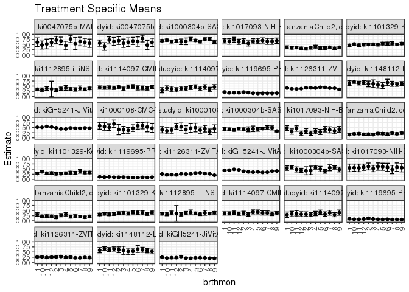

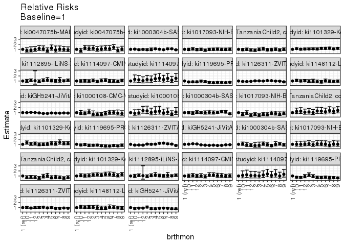

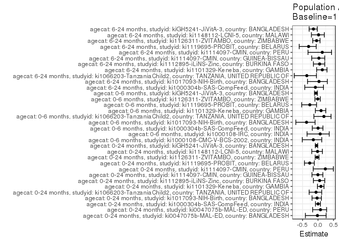

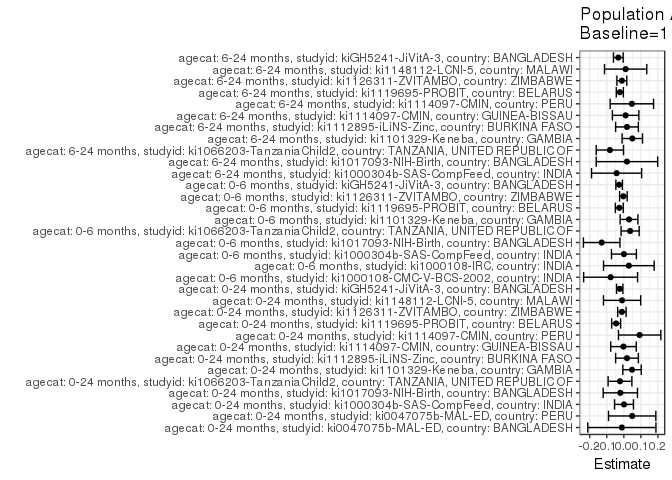

## Results Table

### Parameter: TSM

| agecat | studyid | country | intervention_level | baseline_level | estimate | ci_lower | ci_upper |
| --- | --- | --- | --- | --- | --- | --- | --- |
| 0-24 months | ki0047075b-MAL-ED | BANGLADESH | 1 | NA | 0.6190476 | 0.4109549 | 0.8271403 |
| 0-24 months | ki0047075b-MAL-ED | BANGLADESH | 2 | NA | 0.7200000 | 0.5436626 | 0.8963374 |
| 0-24 months | ki0047075b-MAL-ED | BANGLADESH | 3 | NA | 0.6800000 | 0.4967987 | 0.8632013 |
| 0-24 months | ki0047075b-MAL-ED | BANGLADESH | 4 | NA | 0.4545455 | 0.2460840 | 0.6630069 |
| 0-24 months | ki0047075b-MAL-ED | BANGLADESH | 5 | NA | 0.7727273 | 0.5972809 | 0.9481737 |
| 0-24 months | ki0047075b-MAL-ED | BANGLADESH | 6 | NA | 0.5454545 | 0.2506456 | 0.8402635 |
| 0-24 months | ki0047075b-MAL-ED | BANGLADESH | 7 | NA | 0.6500000 | 0.4405672 | 0.8594328 |
| 0-24 months | ki0047075b-MAL-ED | BANGLADESH | 8 | NA | 0.6153846 | 0.4280280 | 0.8027412 |
| 0-24 months | ki0047075b-MAL-ED | BANGLADESH | 9 | NA | 0.5652174 | 0.3622394 | 0.7681954 |
| 0-24 months | ki0047075b-MAL-ED | BANGLADESH | 10 | NA | 0.4800000 | 0.2837899 | 0.6762101 |
| 0-24 months | ki0047075b-MAL-ED | BANGLADESH | 11 | NA | 0.5294118 | 0.2916938 | 0.7671297 |
| 0-24 months | ki0047075b-MAL-ED | BANGLADESH | 12 | NA | 0.6071429 | 0.4259034 | 0.7883823 |
| 0-24 months | ki0047075b-MAL-ED | PERU | 1 | NA | 0.5714286 | 0.4215174 | 0.7213397 |
| 0-24 months | ki0047075b-MAL-ED | PERU | 2 | NA | 0.6956522 | 0.5072946 | 0.8840098 |
| 0-24 months | ki0047075b-MAL-ED | PERU | 3 | NA | 0.5652174 | 0.3622876 | 0.7681472 |
| 0-24 months | ki0047075b-MAL-ED | PERU | 4 | NA | 0.6190476 | 0.4110044 | 0.8270909 |
| 0-24 months | ki0047075b-MAL-ED | PERU | 5 | NA | 0.6785714 | 0.5053000 | 0.8518429 |
| 0-24 months | ki0047075b-MAL-ED | PERU | 6 | NA | 0.6470588 | 0.4195153 | 0.8746024 |
| 0-24 months | ki0047075b-MAL-ED | PERU | 7 | NA | 0.7916667 | 0.6289205 | 0.9544129 |
| 0-24 months | ki0047075b-MAL-ED | PERU | 8 | NA | 0.4736842 | 0.2488011 | 0.6985673 |
| 0-24 months | ki0047075b-MAL-ED | PERU | 9 | NA | 0.6086957 | 0.4089122 | 0.8084791 |
| 0-24 months | ki0047075b-MAL-ED | PERU | 10 | NA | 0.4074074 | 0.2217652 | 0.5930496 |
| 0-24 months | ki0047075b-MAL-ED | PERU | 11 | NA | 0.7272727 | 0.5750702 | 0.8794753 |
| 0-24 months | ki0047075b-MAL-ED | PERU | 12 | NA | 0.6521739 | 0.4572053 | 0.8471426 |
| 0-24 months | ki1000304b-SAS-CompFeed | INDIA | 1 | NA | 0.6902655 | 0.6351830 | 0.7453480 |
| 0-24 months | ki1000304b-SAS-CompFeed | INDIA | 2 | NA | 0.6373626 | 0.5015763 | 0.7731489 |
| 0-24 months | ki1000304b-SAS-CompFeed | INDIA | 3 | NA | 0.6585366 | 0.4963041 | 0.8207690 |
| 0-24 months | ki1000304b-SAS-CompFeed | INDIA | 4 | NA | 0.7600000 | 0.6667804 | 0.8532196 |
| 0-24 months | ki1000304b-SAS-CompFeed | INDIA | 5 | NA | 0.7029703 | 0.6475550 | 0.7583856 |
| 0-24 months | ki1000304b-SAS-CompFeed | INDIA | 6 | NA | 0.6422018 | 0.5771387 | 0.7072650 |

[output cut: 366 more lines]

### Parameter: E(Y)

| agecat | studyid | country | intervention_level | baseline_level | estimate | ci_lower | ci_upper |
| --- | --- | --- | --- | --- | --- | --- | --- |
| 0-24 months | ki0047075b-MAL-ED | BANGLADESH | NA | NA | 0.6075472 | 0.5486452 | 0.6664491 |
| 0-24 months | ki0047075b-MAL-ED | PERU | NA | NA | 0.6204620 | 0.5657315 | 0.6751926 |
| 0-24 months | ki1000304b-SAS-CompFeed | INDIA | NA | NA | 0.6914547 | 0.6510509 | 0.7318584 |
| 0-24 months | ki1017093-NIH-Birth | BANGLADESH | NA | NA | 0.6645469 | 0.6276196 | 0.7014742 |
| 0-24 months | ki1066203-TanzaniaChild2 | TANZANIA, UNITED REPUBLIC OF | NA | NA | 0.3459933 | 0.3269422 | 0.3650444 |
| 0-24 months | ki1101329-Keneba | GAMBIA | NA | NA | 0.5125214 | 0.4943731 | 0.5306698 |
| 0-24 months | ki1112895-iLiNS-Zinc | BURKINA FASO | NA | NA | 0.3623277 | 0.3130786 | 0.4115769 |
| 0-24 months | ki1114097-CMIN | GUINEA-BISSAU | NA | NA | 0.4286662 | 0.4036720 | 0.4536605 |
| 0-24 months | ki1114097-CMIN | PERU | NA | NA | 0.3928956 | 0.3614728 | 0.4243183 |
| 0-24 months | ki1119695-PROBIT | BELARUS | NA | NA | 0.1674854 | 0.1488048 | 0.1861659 |
| 0-24 months | ki1126311-ZVITAMBO | ZIMBABWE | NA | NA | 0.3966461 | 0.3885633 | 0.4047288 |
| 0-24 months | ki1148112-LCNI-5 | MALAWI | NA | NA | 0.6369048 | 0.6043650 | 0.6694445 |
| 0-24 months | kiGH5241-JiVitA-3 | BANGLADESH | NA | NA | 0.4939812 | 0.4861459 | 0.5018166 |
| 0-6 months | ki1000108-CMC-V-BCS-2002 | INDIA | NA | NA | 0.5108696 | 0.4597270 | 0.5620121 |
| 0-6 months | ki1000108-IRC | INDIA | NA | NA | 0.4243902 | 0.3764905 | 0.4722900 |
| 0-6 months | ki1000304b-SAS-CompFeed | INDIA | NA | NA | 0.4254902 | 0.3977202 | 0.4532601 |
| 0-6 months | ki1017093-NIH-Birth | BANGLADESH | NA | NA | 0.3497615 | 0.3124631 | 0.3870600 |
| 0-6 months | ki1066203-TanzaniaChild2 | TANZANIA, UNITED REPUBLIC OF | NA | NA | 0.1949082 | 0.1790434 | 0.2107729 |
| 0-6 months | ki1101329-Keneba | GAMBIA | NA | NA | 0.3123732 | 0.2940736 | 0.3306728 |
| 0-6 months | ki1119695-PROBIT | BELARUS | NA | NA | 0.0995087 | 0.0864641 | 0.1125533 |
| 0-6 months | ki1126311-ZVITAMBO | ZIMBABWE | NA | NA | 0.2579888 | 0.2507541 | 0.2652234 |
| 0-6 months | kiGH5241-JiVitA-3 | BANGLADESH | NA | NA | 0.4107840 | 0.4033446 | 0.4182233 |
| 6-24 months | ki1000304b-SAS-CompFeed | INDIA | NA | NA | 0.5030750 | 0.4588491 | 0.5473009 |
| 6-24 months | ki1017093-NIH-Birth | BANGLADESH | NA | NA | 0.5739130 | 0.5216565 | 0.6261696 |
| 6-24 months | ki1066203-TanzaniaChild2 | TANZANIA, UNITED REPUBLIC OF | NA | NA | 0.2259675 | 0.2054816 | 0.2464534 |
| 6-24 months | ki1101329-Keneba | GAMBIA | NA | NA | 0.3589489 | 0.3380095 | 0.3798884 |
| 6-24 months | ki1112895-iLiNS-Zinc | BURKINA FASO | NA | NA | 0.3623277 | 0.3130786 | 0.4115769 |
| 6-24 months | ki1114097-CMIN | GUINEA-BISSAU | NA | NA | 0.3714710 | 0.3456477 | 0.3972943 |
| 6-24 months | ki1114097-CMIN | PERU | NA | NA | 0.3450439 | 0.3120195 | 0.3780683 |
| 6-24 months | ki1119695-PROBIT | BELARUS | NA | NA | 0.0768510 | 0.0628857 | 0.0908164 |
| 6-24 months | ki1126311-ZVITAMBO | ZIMBABWE | NA | NA | 0.2459470 | 0.2364841 | 0.2554098 |
| 6-24 months | ki1148112-LCNI-5 | MALAWI | NA | NA | 0.6000000 | 0.5644377 | 0.6355623 |
| 6-24 months | kiGH5241-JiVitA-3 | BANGLADESH | NA | NA | 0.2170724 | 0.2077140 | 0.2264307 |

### Parameter: RR

| agecat | studyid | country | intervention_level | baseline_level | estimate | ci_lower | ci_upper |
| --- | --- | --- | --- | --- | --- | --- | --- |
| 0-24 months | ki0047075b-MAL-ED | BANGLADESH | 1 | 1 | 1.0000000 | 1.0000000 | 1.0000000 |
| 0-24 months | ki0047075b-MAL-ED | BANGLADESH | 2 | 1 | 1.1630769 | 0.7673299 | 1.7629287 |
| 0-24 months | ki0047075b-MAL-ED | BANGLADESH | 3 | 1 | 1.0984615 | 0.7139947 | 1.6899534 |
| 0-24 months | ki0047075b-MAL-ED | BANGLADESH | 4 | 1 | 0.7342657 | 0.4158209 | 1.2965825 |
| 0-24 months | ki0047075b-MAL-ED | BANGLADESH | 5 | 1 | 1.2482517 | 0.8320185 | 1.8727138 |
| 0-24 months | ki0047075b-MAL-ED | BANGLADESH | 6 | 1 | 0.8811189 | 0.4662413 | 1.6651689 |
| 0-24 months | ki0047075b-MAL-ED | BANGLADESH | 7 | 1 | 1.0500000 | 0.6591258 | 1.6726701 |
| 0-24 months | ki0047075b-MAL-ED | BANGLADESH | 8 | 1 | 0.9940828 | 0.6316218 | 1.5645448 |
| 0-24 months | ki0047075b-MAL-ED | BANGLADESH | 9 | 1 | 0.9130435 | 0.5582959 | 1.4932018 |
| 0-24 months | ki0047075b-MAL-ED | BANGLADESH | 10 | 1 | 0.7753846 | 0.4567442 | 1.3163195 |
| 0-24 months | ki0047075b-MAL-ED | BANGLADESH | 11 | 1 | 0.8552036 | 0.4880566 | 1.4985419 |
| 0-24 months | ki0047075b-MAL-ED | BANGLADESH | 12 | 1 | 0.9807692 | 0.6256400 | 1.5374789 |
| 0-24 months | ki0047075b-MAL-ED | PERU | 1 | 1 | 1.0000000 | 1.0000000 | 1.0000000 |
| 0-24 months | ki0047075b-MAL-ED | PERU | 2 | 1 | 1.2173913 | 0.8350185 | 1.7748608 |
| 0-24 months | ki0047075b-MAL-ED | PERU | 3 | 1 | 0.9891304 | 0.6340712 | 1.5430113 |
| 0-24 months | ki0047075b-MAL-ED | PERU | 4 | 1 | 1.0833333 | 0.7073007 | 1.6592817 |
| 0-24 months | ki0047075b-MAL-ED | PERU | 5 | 1 | 1.1875000 | 0.8234548 | 1.7124877 |
| 0-24 months | ki0047075b-MAL-ED | PERU | 6 | 1 | 1.1323529 | 0.7301999 | 1.7559893 |
| 0-24 months | ki0047075b-MAL-ED | PERU | 7 | 1 | 1.3854167 | 0.9927328 | 1.9334300 |
| 0-24 months | ki0047075b-MAL-ED | PERU | 8 | 1 | 0.8289474 | 0.4819019 | 1.4259203 |
| 0-24 months | ki0047075b-MAL-ED | PERU | 9 | 1 | 1.0652174 | 0.6997727 | 1.6215096 |
| 0-24 months | ki0047075b-MAL-ED | PERU | 10 | 1 | 0.7129630 | 0.4214232 | 1.2061894 |
| 0-24 months | ki0047075b-MAL-ED | PERU | 11 | 1 | 1.2727273 | 0.9098913 | 1.7802508 |
| 0-24 months | ki0047075b-MAL-ED | PERU | 12 | 1 | 1.1413043 | 0.7667703 | 1.6987820 |
| 0-24 months | ki1000304b-SAS-CompFeed | INDIA | 1 | 1 | 1.0000000 | 1.0000000 | 1.0000000 |
| 0-24 months | ki1000304b-SAS-CompFeed | INDIA | 2 | 1 | 0.9233587 | 0.7544678 | 1.1300565 |
| 0-24 months | ki1000304b-SAS-CompFeed | INDIA | 3 | 1 | 0.9540338 | 0.7177800 | 1.2680494 |
| 0-24 months | ki1000304b-SAS-CompFeed | INDIA | 4 | 1 | 1.1010256 | 0.9550400 | 1.2693263 |
| 0-24 months | ki1000304b-SAS-CompFeed | INDIA | 5 | 1 | 1.0184057 | 0.8978374 | 1.1551647 |
| 0-24 months | ki1000304b-SAS-CompFeed | INDIA | 6 | 1 | 0.9303693 | 0.8226139 | 1.0522397 |

[output cut: 366 more lines]

### Parameter: PAR

| agecat | studyid | country | intervention_level | baseline_level | estimate | ci_lower | ci_upper |
| --- | --- | --- | --- | --- | --- | --- | --- |
| 0-24 months | ki0047075b-MAL-ED | BANGLADESH | 1 | NA | -0.0115004 | -0.2112727 | 0.1882718 |
| 0-24 months | ki0047075b-MAL-ED | PERU | 1 | NA | 0.0490335 | -0.0896696 | 0.1877366 |
| 0-24 months | ki1000304b-SAS-CompFeed | INDIA | 1 | NA | 0.0011892 | -0.0543226 | 0.0567009 |
| 0-24 months | ki1017093-NIH-Birth | BANGLADESH | 1 | NA | -0.0203846 | -0.1208715 | 0.0801023 |
| 0-24 months | ki1066203-TanzaniaChild2 | TANZANIA, UNITED REPUBLIC OF | 1 | NA | -0.0224277 | -0.0920404 | 0.0471850 |
| 0-24 months | ki1101329-Keneba | GAMBIA | 1 | NA | 0.0481147 | -0.0058636 | 0.1020929 |
| 0-24 months | ki1112895-iLiNS-Zinc | BURKINA FASO | 1 | NA | 0.0186745 | -0.0479956 | 0.0853445 |
| 0-24 months | ki1114097-CMIN | GUINEA-BISSAU | 1 | NA | -0.0017974 | -0.0767317 | 0.0731370 |
| 0-24 months | ki1114097-CMIN | PERU | 1 | NA | 0.0928956 | -0.0312024 | 0.2169936 |
| 0-24 months | ki1119695-PROBIT | BELARUS | 1 | NA | -0.0449903 | -0.0712247 | -0.0187559 |
| 0-24 months | ki1126311-ZVITAMBO | ZIMBABWE | 1 | NA | -0.0112776 | -0.0360610 | 0.0135058 |
| 0-24 months | ki1148112-LCNI-5 | MALAWI | 1 | NA | -0.0101541 | -0.1191689 | 0.0988608 |
| 0-24 months | kiGH5241-JiVitA-3 | BANGLADESH | 1 | NA | -0.0240554 | -0.0426427 | -0.0054682 |
| 0-6 months | ki1000108-CMC-V-BCS-2002 | INDIA | 1 | NA | -0.0773657 | -0.2354350 | 0.0807036 |
| 0-6 months | ki1000108-IRC | INDIA | 1 | NA | 0.0296534 | -0.1187314 | 0.1780382 |
| 0-6 months | ki1000304b-SAS-CompFeed | INDIA | 1 | NA | 0.0007114 | -0.0722036 | 0.0736264 |
| 0-6 months | ki1017093-NIH-Birth | BANGLADESH | 1 | NA | -0.1296905 | -0.2368923 | -0.0224887 |
| 0-6 months | ki1066203-TanzaniaChild2 | TANZANIA, UNITED REPUBLIC OF | 1 | NA | 0.0370134 | -0.0160280 | 0.0900549 |
| 0-6 months | ki1101329-Keneba | GAMBIA | 1 | NA | 0.0305199 | -0.0215100 | 0.0825498 |
| 0-6 months | ki1119695-PROBIT | BELARUS | 1 | NA | -0.0263450 | -0.0494895 | -0.0032005 |
| 0-6 months | ki1126311-ZVITAMBO | ZIMBABWE | 1 | NA | -0.0024969 | -0.0246679 | 0.0196741 |
| 0-6 months | kiGH5241-JiVitA-3 | BANGLADESH | 1 | NA | -0.0274316 | -0.0465753 | -0.0082879 |
| 6-24 months | ki1000304b-SAS-CompFeed | INDIA | 1 | NA | -0.0423795 | -0.1892117 | 0.1044527 |
| 6-24 months | ki1017093-NIH-Birth | BANGLADESH | 1 | NA | 0.0183575 | -0.1617764 | 0.1984914 |
| 6-24 months | ki1066203-TanzaniaChild2 | TANZANIA, UNITED REPUBLIC OF | 1 | NA | -0.0817248 | -0.1616986 | -0.0017509 |
| 6-24 months | ki1101329-Keneba | GAMBIA | 1 | NA | 0.0497702 | -0.0101477 | 0.1096881 |
| 6-24 months | ki1112895-iLiNS-Zinc | BURKINA FASO | 1 | NA | 0.0186745 | -0.0479956 | 0.0853445 |
| 6-24 months | ki1114097-CMIN | GUINEA-BISSAU | 1 | NA | 0.0105688 | -0.0669955 | 0.0881330 |
| 6-24 months | ki1114097-CMIN | PERU | 1 | NA | 0.0471716 | -0.0800584 | 0.1744016 |
| 6-24 months | ki1119695-PROBIT | BELARUS | 1 | NA | -0.0233742 | -0.0439199 | -0.0028285 |
| 6-24 months | ki1126311-ZVITAMBO | ZIMBABWE | 1 | NA | -0.0113779 | -0.0403661 | 0.0176104 |
| 6-24 months | ki1148112-LCNI-5 | MALAWI | 1 | NA | 0.0107143 | -0.1131374 | 0.1345660 |
| 6-24 months | kiGH5241-JiVitA-3 | BANGLADESH | 1 | NA | -0.0321641 | -0.0606116 | -0.0037165 |

### Parameter: PAF

| agecat | studyid | country | intervention_level | baseline_level | estimate | ci_lower | ci_upper |
| --- | --- | --- | --- | --- | --- | --- | --- |
| 0-24 months | ki0047075b-MAL-ED | BANGLADESH | 1 | NA | -0.0189293 | -0.4070175 | 0.2621151 |
| 0-24 months | ki0047075b-MAL-ED | PERU | 1 | NA | 0.0790274 | -0.1742653 | 0.2776840 |
| 0-24 months | ki1000304b-SAS-CompFeed | INDIA | 1 | NA | 0.0017198 | -0.0818385 | 0.0788244 |
| 0-24 months | ki1017093-NIH-Birth | BANGLADESH | 1 | NA | -0.0306744 | -0.1935750 | 0.1099932 |
| 0-24 months | ki1066203-TanzaniaChild2 | TANZANIA, UNITED REPUBLIC OF | 1 | NA | -0.0648213 | -0.2862866 | 0.1185135 |
| 0-24 months | ki1101329-Keneba | GAMBIA | 1 | NA | 0.0938783 | -0.0178589 | 0.1933494 |
| 0-24 months | ki1112895-iLiNS-Zinc | BURKINA FASO | 1 | NA | 0.0515403 | -0.1478583 | 0.2163006 |
| 0-24 months | ki1114097-CMIN | GUINEA-BISSAU | 1 | NA | -0.0041929 | -0.1951390 | 0.1562459 |
| 0-24 months | ki1114097-CMIN | PERU | 1 | NA | 0.2364384 | -0.1547569 | 0.4951090 |
| 0-24 months | ki1119695-PROBIT | BELARUS | 1 | NA | -0.2686222 | -0.4376818 | -0.1194426 |
| 0-24 months | ki1126311-ZVITAMBO | ZIMBABWE | 1 | NA | -0.0284325 | -0.0928530 | 0.0321906 |
| 0-24 months | ki1148112-LCNI-5 | MALAWI | 1 | NA | -0.0159428 | -0.2023759 | 0.1415830 |
| 0-24 months | kiGH5241-JiVitA-3 | BANGLADESH | 1 | NA | -0.0486971 | -0.0870390 | -0.0117076 |
| 0-6 months | ki1000108-CMC-V-BCS-2002 | INDIA | 1 | NA | -0.1514393 | -0.5070942 | 0.1202856 |
| 0-6 months | ki1000108-IRC | INDIA | 1 | NA | 0.0698730 | -0.3546046 | 0.3613367 |
| 0-6 months | ki1000304b-SAS-CompFeed | INDIA | 1 | NA | 0.0016720 | -0.1852750 | 0.1591329 |
| 0-6 months | ki1017093-NIH-Birth | BANGLADESH | 1 | NA | -0.3707970 | -0.7157773 | -0.0951797 |
| 0-6 months | ki1066203-TanzaniaChild2 | TANZANIA, UNITED REPUBLIC OF | 1 | NA | 0.1899019 | -0.1331480 | 0.4208534 |
| 0-6 months | ki1101329-Keneba | GAMBIA | 1 | NA | 0.0977035 | -0.0852035 | 0.2497822 |
| 0-6 months | ki1119695-PROBIT | BELARUS | 1 | NA | -0.2647507 | -0.5267144 | -0.0477364 |
| 0-6 months | ki1126311-ZVITAMBO | ZIMBABWE | 1 | NA | -0.0096783 | -0.0993793 | 0.0727038 |
| 0-6 months | kiGH5241-JiVitA-3 | BANGLADESH | 1 | NA | -0.0667787 | -0.1144558 | -0.0211412 |
| 6-24 months | ki1000304b-SAS-CompFeed | INDIA | 1 | NA | -0.0842409 | -0.4276894 | 0.1765867 |
| 6-24 months | ki1017093-NIH-Birth | BANGLADESH | 1 | NA | 0.0319865 | -0.3387739 | 0.3000685 |
| 6-24 months | ki1066203-TanzaniaChild2 | TANZANIA, UNITED REPUBLIC OF | 1 | NA | -0.3616660 | -0.7654315 | -0.0502442 |
| 6-24 months | ki1101329-Keneba | GAMBIA | 1 | NA | 0.1386554 | -0.0455346 | 0.2903969 |
| 6-24 months | ki1112895-iLiNS-Zinc | BURKINA FASO | 1 | NA | 0.0515403 | -0.1478583 | 0.2163006 |
| 6-24 months | ki1114097-CMIN | GUINEA-BISSAU | 1 | NA | 0.0284511 | -0.2044890 | 0.2163422 |
| 6-24 months | ki1114097-CMIN | PERU | 1 | NA | 0.1367118 | -0.3232599 | 0.4367951 |
| 6-24 months | ki1119695-PROBIT | BELARUS | 1 | NA | -0.3041491 | -0.6066211 | -0.0586223 |
| 6-24 months | ki1126311-ZVITAMBO | ZIMBABWE | 1 | NA | -0.0462615 | -0.1710159 | 0.0652022 |
| 6-24 months | ki1148112-LCNI-5 | MALAWI | 1 | NA | 0.0178571 | -0.2118637 | 0.2040321 |
| 6-24 months | kiGH5241-JiVitA-3 | BANGLADESH | 1 | NA | -0.1481720 | -0.2870892 | -0.0242484 |